# Survival Model Selection and Validation for HEOR in R

An HTA-aligned workflow for fitting, diagnosing, comparing, and justifying parametric survival models

Xin (David) Zhao

2026-08-17

## Introduction

In health economic evaluations such as cost-effectiveness analyses, estimating the long-term health benefits of innovative treatments over a lifetime horizon is essential. However, randomized controlled trials (RCTs) typically have short follow-up periods. Therefore, following health technology assessment (HTA) guidelines, it is important to extrapolate survival data in a statistically robust and clinically justified manner to predict life expectancy for both new treatments and standard care.

This R notebook provides a reusable, HTA-oriented framework showing not only how to fit survival models in R, but also how to evaluate, compare, interpret, and defend the model selected for economic evaluation.

## Defensible workflow and R tools

### NICE-recommended survival extrapolation workflow

NICE TSD14 recommends a structured four-step procedure to ensure that survival extrapolations are both statistically sound and clinically credible.

Each step builds on the last, guiding the analyst from exploratory data inspection through to a fully justified model selection that can withstand scrutiny in a health technology appraisal.

**Step 1 — Assess model assumptions & hazard structure**

Examine the observed data with graphical and statistical tools to understand which survival and hazard shapes are plausible before selecting a model.

**Step 2 — Fit candidate models**

Fit the full standard parametric family (Exponential, Weibull, Gompertz, Log-normal, Log-logistic, Generalized Gamma) and flexible alternatives where justified.

**Step 3 — Evaluate statistical fit & graphical diagnostics**

Compare fitted curves against the Kaplan-Meier estimate using AIC/BIC and residual diagnostics. Visually inspect hazard plots, probability plots, and residual plots to detect systematic departures.

**Step 4 — Evaluate external validity & decision uncertainty**

Assess whether the extrapolated curves are clinically plausible, consistent with external evidence, and robust to alternative model choices.

### R packages

Three specialized R packages were used to implement the workflow:

- `survival`: Fit Kaplan-Meier curves and create visualizations (e.g., cumulative hazard plots)
- `flexsurv`: Fit parametric and flexible survival models, perform residual diagnostics, and create visualizations
- `GofCens`: Assess goodness of fit and create visualizations

```r
# Install required packages
required_pkgs <- c("survival", "flexsurv", "GofCens")

for (pkg in required_pkgs) {
    if (!requireNamespace(pkg, quietly = TRUE)) {
        install.packages(pkg)
}
}
```

```r
# Load required packages

invisible(lapply(required_pkgs, library, character.only = TRUE))
```

## Input data

The input data, censored time-to-event data (locoregional control), were digitized from an RCT by [Bonner et al., 2006](https://www.nejm.org/doi/full/10.1056/NEJMoa053422), which investigated the effect of cetuximab treatment on patients with head and neck cancer.

The `IPD_ctrl_gp.csv` and `IPD_treat_gp.csv` files contain time-to-event data for the control (n=213) and treatment (n=211) arms, with a follow-up duration of 50 months.

```r
# Control arm
ipd_ctrl <- read.csv("IPD_ctrl_gp.csv")

# Treatment arm
ipd_trt <- read.csv("IPD_treat_gp.csv")

# Merge the datasets from the two arms
ipd_merged <- rbind(ipd_ctrl, ipd_trt)
```

Inspect the first rows of the combined dataset. The columns are defined as follows:

- `time`: Follow-up time in months.
- `status`: 1 indicates an event; 0 indicates censoring.
- `treat`: 1 indicates treatment; 0 indicates control.

```r
# Inspect the first rows of the merged dataset
head(ipd_merged, 15)
```

```
##       time status treat
## 1  0.00274      1     0
## 2  0.00274      1     0
## 3  0.26100      1     0
## 4  0.77900      1     0
## 5  0.77900      1     0
## 6  0.77900      1     0
## 7  1.03450      0     0
## 8  1.29000      1     0
## 9  1.81000      1     0
## 10 2.07000      1     0
## 11 2.33000      0     0
## 12 2.59000      1     0
## 13 2.59000      1     0
## 14 2.85000      1     0
## 15 2.85000      1     0
```

## Step 1 - Assess model assumptions & hazard structure

Use graphical and statistical tools to determine which survival and hazard shapes are plausible before selecting a model.

### Step 1.1 Log cumulative hazard plot

A (log) cumulative hazard plot is recommended to answer key questions:

- Are proportional hazards reasonable?
- What hazard shape is supported?

```r
# Fit Kaplan-Meier curves, stratified by treatment groups
surv_km <- survival::survfit(Surv(time, status) ~ treat,
  data = ipd_merged,
  type = "kaplan-meier"
)
```

To assess whether hazards are constant over time (e.g., exponential distribution), plot cumulative hazard versus time. To evaluate monotonic changes in hazard (e.g., Weibull and Gompertz distributions), plot the logarithm of cumulative hazard against the logarithm of time.

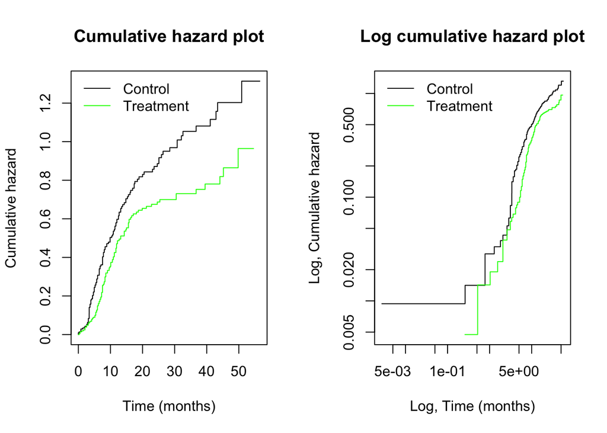

Figure 1. Log cumulative hazard plots for the control and treatment arms.

```r
# Plot cumulative hazard
old_par <- par(no.readonly = TRUE)

par(mfrow = c(1, 2)) # Set up a 1x2 plotting area

plot(surv_km,
  fun = "cumhaz",
  xlab = "Time (months)",
  ylab = "Cumulative hazard",
  col = c("black", "green"),
  main = "Cumulative hazard plot"
)

legend("topleft",
  legend = c("Control", "Treatment"),
  col = c("black", "green"),
  lty = 1,
  lwd = 1,
  bty = "n"
)

# Use logarithmic scales for both axes
plot(surv_km,
  fun = "cumhaz",
  log = "xy",
  xlab = "Log, Time (months)",
  ylab = "Log, Cumulative hazard",
  col = c("black", "green"),
  main = "Log cumulative hazard plot"
)

legend("topleft",
  legend = c("Control", "Treatment"),
  col = c("black", "green"),
  lty = 1,
  lwd = 1,
  bty = "n"
)
```

The cumulative hazard curves (left) change slope around 10–20 months, suggesting that the hazard may vary over follow-up. A constant-hazard exponential model therefore appears questionable over the full period. Piecewise or more flexible models may warrant consideration.

On the log-cumulative-hazard scale (right), approximate linearity over a sustained interval would support further consideration of Weibull-type models. The apparent early and later departures from linearity should be examined before concluding that one distribution is suitable. Gompertz and other families should be evaluated using appropriate distribution-specific diagnostics.

### Step 1.2 Overlay KM curves and parametric model curves

Overlaying KM curves and fitted parametric model curves allows visual assessment of goodness of fit for candidate parametric survival models.

```r
# Define a list of datasets for the two arms for loop iterations
data_list  <- list(
  ipd_ctrl = ipd_ctrl,
  ipd_trt = ipd_trt
)


# Define a vector of recommended parametric models for loop iterations
distr_list <- c(
  "exponential",
  "weibull",
  "gompertz",
  "lognormal",
  'loglogistic',
  "llogis"
)
```

The package `flexsurv` can fit a variety of parametric survival models effectively. The plot shows fitted and observed data for the control and treatment arms separately.

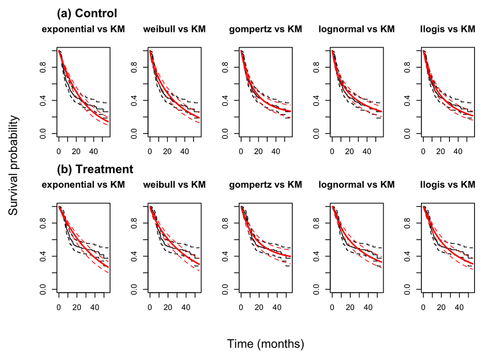

```r
# Create space for global axis labels
par(
  mfrow = c(2, 5),
  oma = c(4, 4, 1, 1),   # outer margins
  mar = c(3, 2, 4, 2)    # smaller margins for individual plots
)

for (data_name in names(data_list)) {

  data <- data_list[[data_name]]

  for (distr in distr_list) {

    tryCatch(
      {
        fit <- flexsurv::flexsurvreg(
          survival::Surv(time, status) ~ 1,
          data = data,
          dist = distr
        )

        plot(
          fit,
          type = "survival",
          ci = TRUE,
          main = paste(distr, "vs KM"),
          xlab = "",
          ylab = ""
        )

        if (distr == distr_list[1]) {

          panel_label <- if (data_name == names(data_list)[1]) {
            "(a) Control"
          } else {
            "(b) Treatment"
          }

          mtext(
            panel_label,
            side = 3,
            line = 3,
            adj = 0,
            font = 2,
            cex = 1
          )}
      },
      error = function(error_message) {
        warning(
          "Model failed for dataset '", data_name,
          "' with distribution '", distr, "': ",
          conditionMessage(error_message)
        )
      }
    )
  }
}

# Global axis labels
mtext(
  "Time (months)",
  side = 1,
  outer = TRUE,
  line = 2
)

mtext(
  "Survival probability",
  side = 2,
  outer = TRUE,
  line = 2
)
```

Within the observed period, Gompertz, log-normal and log-logistic appear visually closer to the KM estimates than exponential or Weibull. This is only a preliminary internal-fit assessment. Interpretation should account for numbers at risk and censoring, particularly in the tail, and should be combined with statistical diagnostics and assessment of long-term plausibility.

### Step 1.3 Q-Q plots for right-censored data

The purpose of using Q-Q plots is to determine whether specific distribution families are compatible with the observed data.

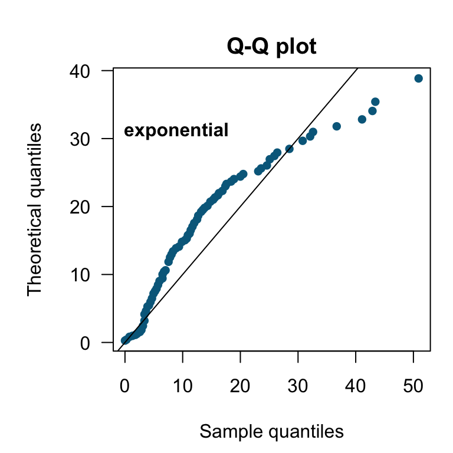

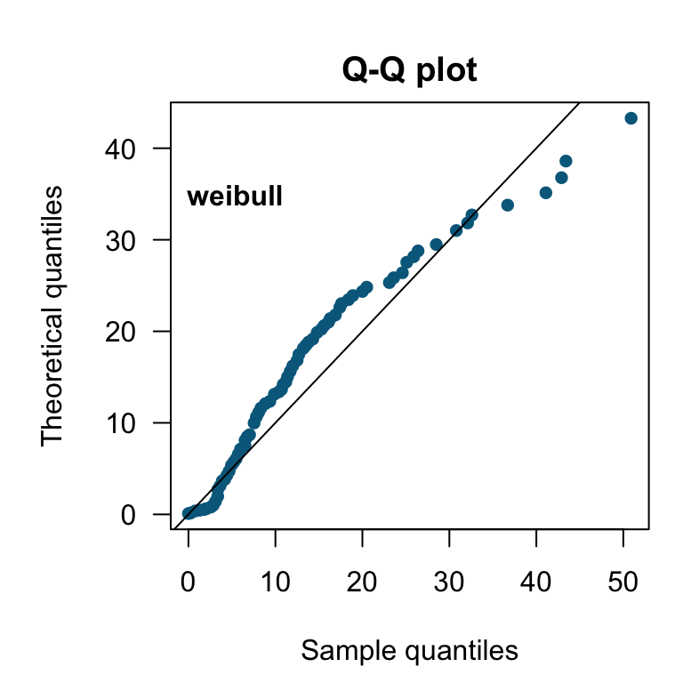

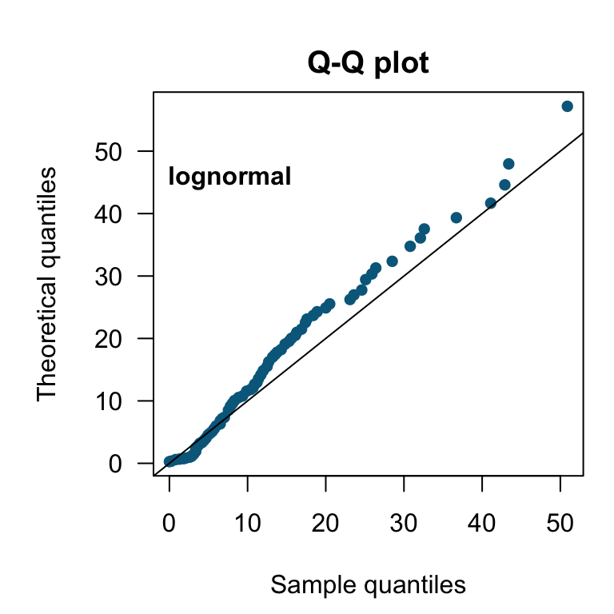

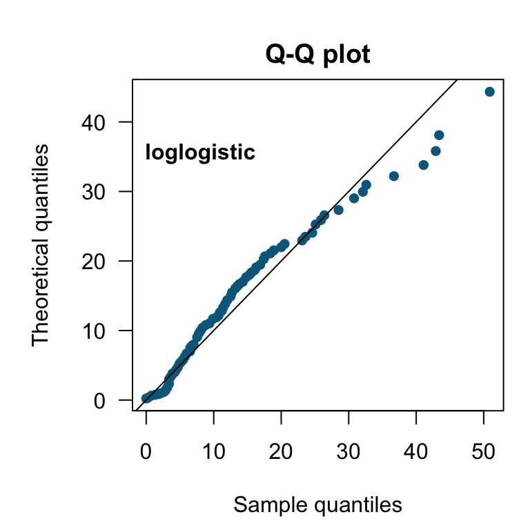

```r
for (distr in distr_list) {

  tryCatch(
    {

    GofCens::probPlot(
        ipd_ctrl$time,
        ipd_ctrl$status,
        distr = distr,
        plots = "QQ",
        mtitle = FALSE,
        ggplo = FALSE,
        prnt = FALSE
      )

    usr <- par("usr")

    text(x = usr[1] + 0.10 * (usr[2] - usr[1]),
         y = usr[4] - 0.12 * (usr[4] - usr[3]),
         labels = distr,
         adj = c(0, 1),
         font = 2,
         cex = 1)

    },
    error = function(error_message) {
      warning(
        "Distribution '", distr,
        "' is not available for GofCens::probPlot(): ",
        conditionMessage(error_message)
      )
    }
  )
}
```

The censored Q–Q plots show departures from the reference line for each evaluated family, particularly at later quantiles where information may be sparse. These plots do not clearly identify a single preferred distribution and should be treated as screening evidence alongside arm-specific hazard plots, residual diagnostics, AIC/BIC and clinical plausibility. Gompertz cannot be evaluated by this implementation due to software limitations and should be assessed using other diagnostics.

### Step 1.4 Residual plots (Cox-Snell)

Residual plots can detect systematic lack of fit in candidate models.

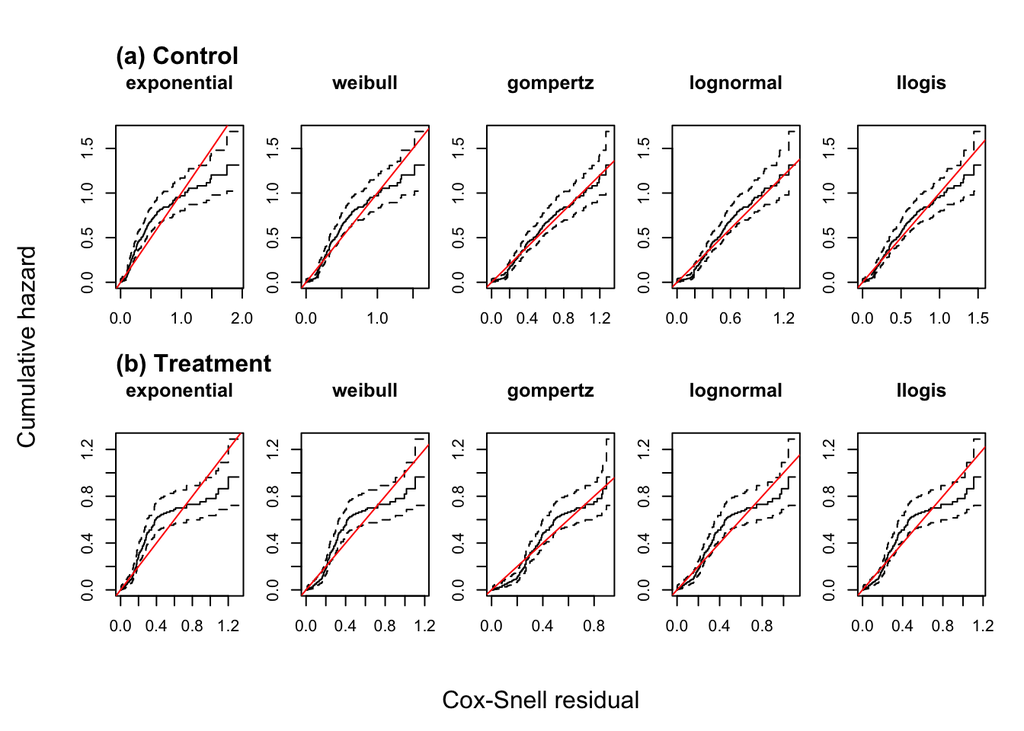

```r
par(
  mfrow = c(2, 5),
  oma = c(4, 4, 2, 1),   # outer margins
  mar = c(3, 2, 4.5, 1)    # individual plot margins
)

for (data_name in names(data_list)) {

  data <- data_list[[data_name]]

  for (distr in distr_list) {

    tryCatch(
      {
        # Fit parametric survival model
        fit <- flexsurv::flexsurvreg(
          survival::Surv(time, status) ~ 1,
          data = data,
          dist = distr
        )

        # Cox-Snell residuals
        cs <- flexsurv::coxsnell_flexsurvreg(fit)

        # Estimate cumulative hazard of residuals
        surv <- survival::survfit(
          survival::Surv(cs$est, data$status) ~ 1
        )

        # Plot
        plot(
          surv,
          fun = "cumhaz",
          main = distr,
          xlab = "",
          ylab = ""
        )

        # Ideal Cox-Snell reference line
        abline(0, 1, col = "red")

        if (distr == distr_list[1]) {

          panel_label <- if (data_name == names(data_list)[1]) {
            "(a) Control"
          } else {
            "(b) Treatment"
          }

          mtext(
            panel_label,
            side = 3,
            line = 3,
            adj = 0,
            font = 2,
            cex = 1
          )
}
      },
      error = function(error_message) {
        warning(
          "Model failed for dataset '", data_name,
          "' with distribution '", distr, "': ",
          conditionMessage(error_message)
        )
      }
    )
  }
}


# Global axis labels
mtext(
  "Cox-Snell residual",
  side = 1,
  outer = TRUE,
  line = 2
)

mtext(
  "Cumulative hazard",
  side = 2,
  outer = TRUE,
  line = 2
)
```

For a well-fitting model, the estimated cumulative hazard of the Cox–Snell residuals should lie approximately along the 45° line. Several candidates track the line over much of the observed range, with differing localized departures and increasing uncertainty toward the tail. These plots provide no definitive basis on their own for selecting a particular distribution and should be interpreted with the other diagnostics.

## Step 2. Fit common parametric survival models to both arms

Fit the same candidate distribution type to both arms, allowing arm-specific scale and, where appropriate, shape parameters. A treatment-covariate PH parameterization should be used only if PH is adequately supported. If different distribution families are selected for the two arms, provide strong statistical, biological and clinical justification.

```r
model_distr_list <- c(
  "exponential",
  "weibull",
  "gompertz",
  "lognormal",
  "llogis",
  "gengamma"
)

fitted_models <- lapply(model_distr_list, function(distr) {
  flexsurv::flexsurvreg(
    Surv(time, status) ~ treat,
    data = ipd_merged,
    dist = distr
  )
})

names(fitted_models) <- model_distr_list
```

### Step 3.1 Evaluate the AIC of fitted models

Evaluate the relative fit of models fitted to the same observed data, accounting for model complexity, using the Akaike information criterion (AIC).

AIC does not establish absolute adequacy, robustness or the credibility of the extrapolated tail; those questions require graphical diagnostics, assessment of censoring, clinical plausibility and external validation.

```r
aic_values <- sapply(fitted_models, function(model) {
  model$AIC
})

# Create a data frame to display AIC values for each distribution
aic_df <- data.frame(
  Distribution = names(aic_values),
  AIC = aic_values
)

# Drop row names
rownames(aic_df) <- NULL

# Sort the data frame by AIC values in ascending order
aic_df <- aic_df[order(aic_df$AIC), ]

aic_df # gompertz has the lowest AIC value
```

```
##   Distribution      AIC
## 3     gompertz 2173.631
## 5       llogis 2179.306
## 6     gengamma 2191.250
## 4    lognormal 2198.150
## 2      weibull 2204.574
## 1  exponential 2215.113
```

Among the fitted candidates, Gompertz has the lowest AIC and therefore the strongest relative support for fit to the observed data after accounting for model complexity.

### Step 3.2 Compare KM curves with fitted models

As a complementary evaluation, we visually inspect the fitted model curves by comparing them with nonparametric Kaplan-Meier curves for the control and treatment arms separately.

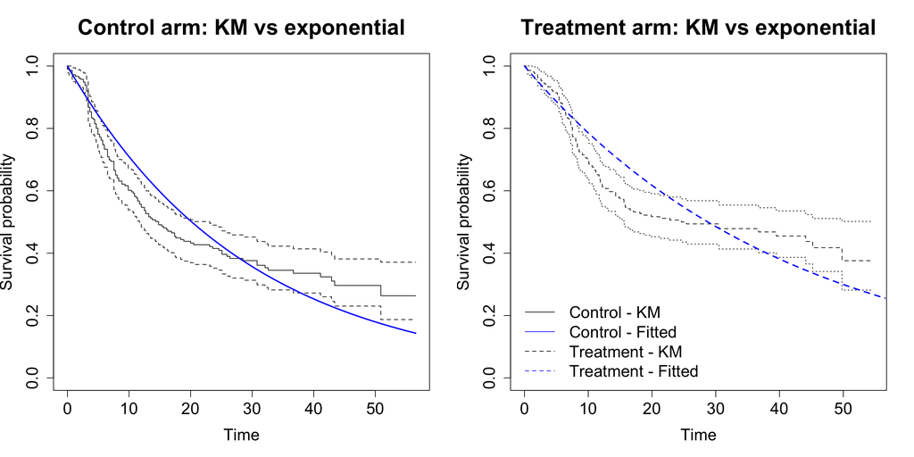

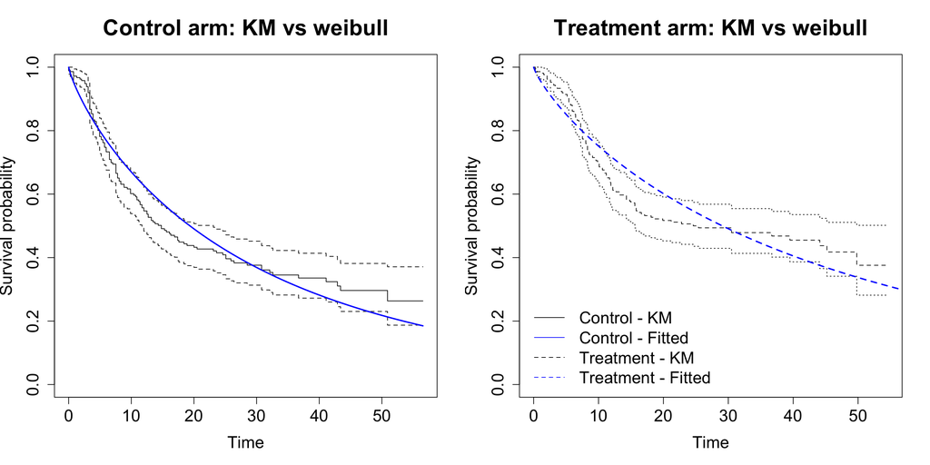

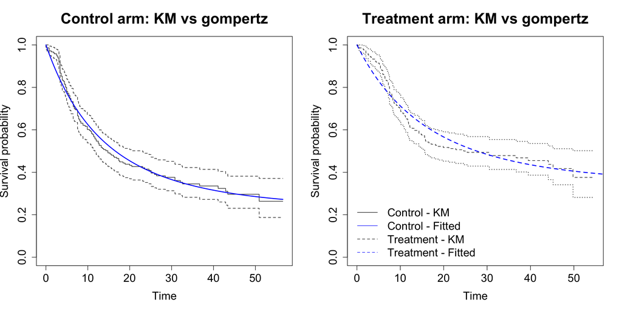

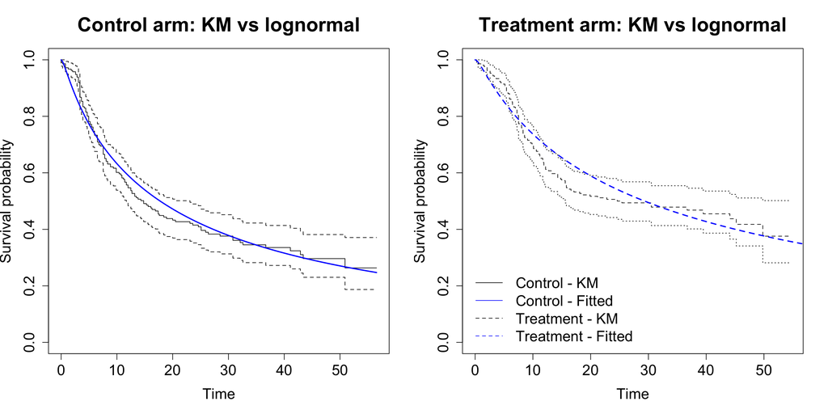

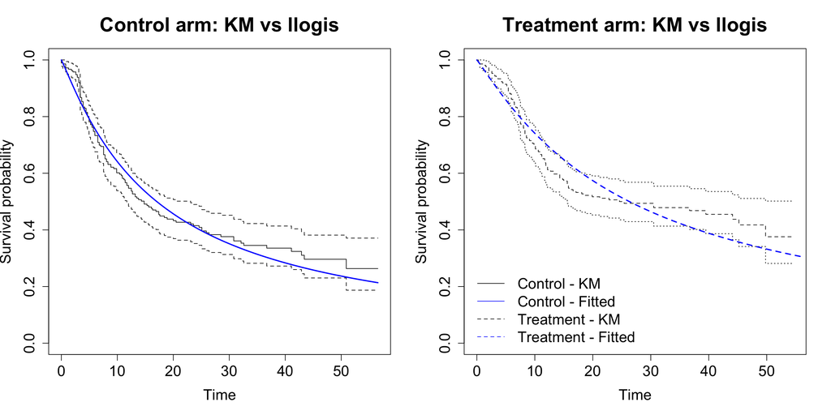

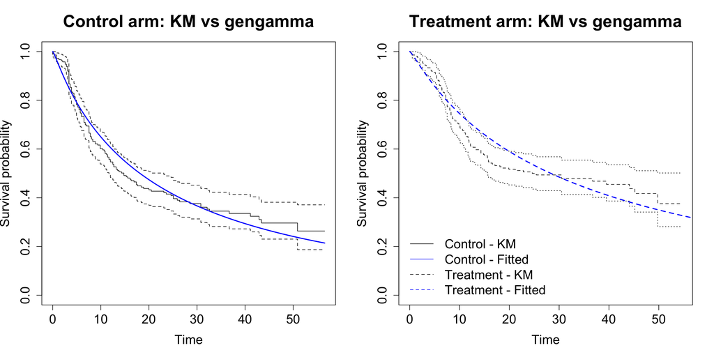

```r
par(mfrow = c(6, 2),
    cex.main = 2,
    cex.axis = 1.5,
    cex.lab = 1.5)


for (mod in names(fitted_models)) {

  par(mfrow = c(1, 2))

  # Control arm

  km_ctrl <- survfit(Surv(time, status) ~ 1,
  data = ipd_merged[ipd_merged$treat == 0, ])

  plot(
    km_ctrl,
    main = paste("Control arm: KM vs", mod),
    xlab = "Time",
    ylab = "Survival probability",
    lty = 1,
    col = "black",
    mark.time = FALSE
  )

  lines(
    fitted_models[[mod]],
    newdata = data.frame(treat = 0),
    type = "survival",
    ci = FALSE,
    lty = 1,
    col = "blue"
  )

  # Treatment arm

  km_trt <- survfit(Surv(time, status) ~ 1,
  data = ipd_merged[ipd_merged$treat == 1, ])

  plot(
    km_trt,
    main = paste("Treatment arm: KM vs", mod),
    xlab = "Time",
    ylab = "Survival probability",
    lty = 2,
    mark.time = FALSE,
    col = "black"
  )

  lines(
    fitted_models[[mod]],
    newdata = data.frame(treat = 1),
    type = "survival",
    ci = FALSE,
    lty = 2,
    col = "blue"
  )

  legend(
    "bottomleft",
    legend = c(
      "Control - KM",
      "Control - Fitted",
      "Treatment - KM",
      "Treatment - Fitted"
    ),
    col = c("black", "blue", "black", "blue"),
    lty = c(1, 1, 2, 2),
    lwd = 1,
    bty = "n",
    cex = 1.5
  )

}
```

Gompertz has favorable AIC and generally acceptable graphical fit within the observed period, but log-normal and log-logistic also remain plausible on some diagnostics. The evidence supports retaining a set of candidate models rather than declaring Gompertz uniquely best. Selection of a base-case model should additionally reflect the completeness of follow-up and the clinical plausibility of each extrapolated tail.

## Survival extrapolation and validation

```r
require(tidyr)
require(dplyr)
require(ggplot2)


times <- 0:120

pr_long <- dplyr::data_frame()

for (mod in names(fitted_models)) {

  pr <- summary(fitted_models[[mod]],
              newdata = data.frame(treat = c(0, 1)),
              type = "survival",
              t = times)

  pr_control <- as.data.frame(pr[[1]]) |>
    dplyr::mutate(group = "Control") |>
    dplyr::mutate(model = mod)

  pr_treatment <- as.data.frame(pr[[2]]) |>
    dplyr::mutate(group = "Treatment") |>
    dplyr::mutate(model = mod)

  pr_long <- dplyr::bind_rows(
    pr_long,
    pr_control,
    pr_treatment
)

}
```

```r
head(pr_long, 10)
```

```
## # A tibble: 10 × 6
##     time   est   lcl   ucl group   model
##    <int> <dbl> <dbl> <dbl> <chr>   <chr>
##  1     0 1     1     1     Control exponential
##  2     1 0.966 0.960 0.971 Control exponential
##  3     2 0.934 0.922 0.943 Control exponential
##  4     3 0.902 0.885 0.916 Control exponential
##  5     4 0.872 0.849 0.890 Control exponential
##  6     5 0.842 0.815 0.864 Control exponential
##  7     6 0.814 0.783 0.840 Control exponential
##  8     7 0.786 0.751 0.816 Control exponential
##  9     8 0.760 0.721 0.792 Control exponential
## 10     9 0.734 0.693 0.769 Control exponential
```

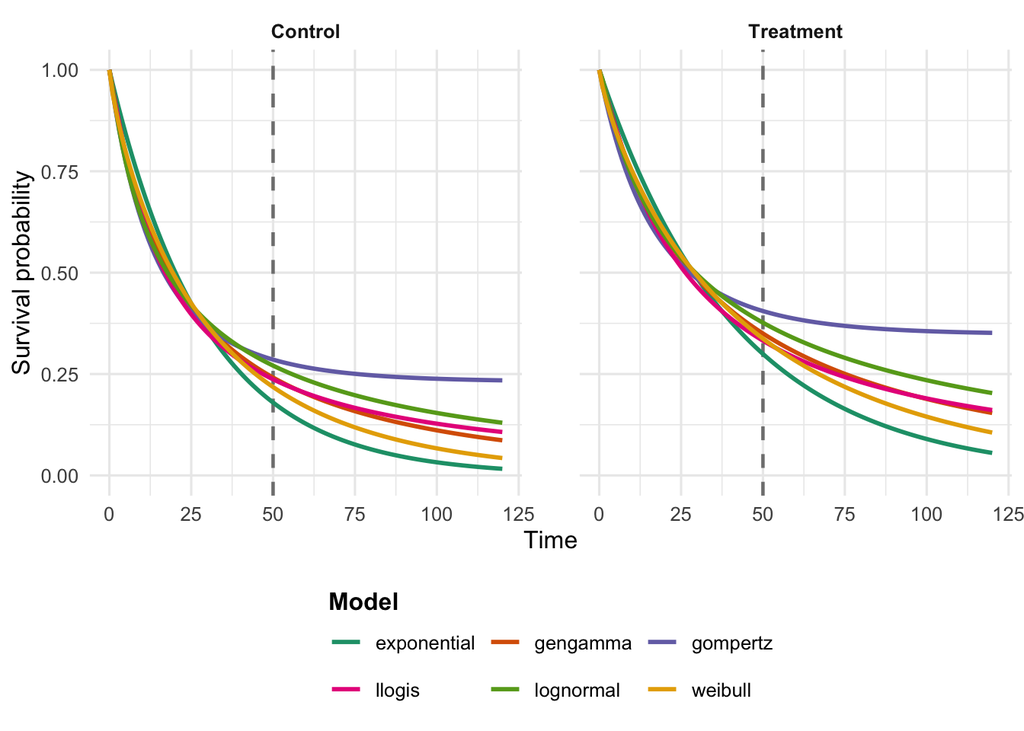

```r
ggplot(pr_long, aes(x = time,
                    y = est,
                    color = model,
                    group = model)) +
  geom_vline(
    xintercept = 50,
    color = "grey50",
    linetype = "dashed",
    linewidth = 0.8
  ) +
  geom_line(linewidth = 1) +
  facet_wrap(
    ~ group,
    nrow = 1) +
  scale_color_brewer(
    palette = "Dark2",
    name = "Model"
  ) +
  scale_y_continuous(
    limits = c(0, 1),
    breaks = seq(0, 1, 0.25)
  ) +
  labs(
    x = "Time",
    y = "Survival probability"
  ) +
  theme_minimal(base_size = 12) +
  theme(
    legend.position = "bottom",
    legend.title.position = "top",
    legend.title = element_text(face = "bold"),
    strip.text = element_text(face = "bold"),
    panel.spacing = grid::unit(1, "cm")
  ) +
  guides(
    color = guide_legend(
      nrow = 2,
      byrow = TRUE
    )
  )
```

The extrapolated curves should not be considered validated solely because they fit the trial data. For each plausible model, report long-term survival and hazard predictions at decision-relevant time points and compare them with relevant registries, longer-term studies, background mortality, biological expectations and clinical-expert judgement. Discuss the comparability and limitations of each external source.

The base-case extrapolation assumes constant treatment effect throughout the period of interest, but this assumption should be critically evaluated in light of treatment-effect duration. Because post-trial relative effects are uncertain, evaluate at least three scenarios: treatment effect stops at the end of observed follow-up, wanes over a clinically justified period, or persists over the lifetime horizon. The assumptions should be informed by observed hazards, mechanism of action and clinical advice.

## Model Selection & Validation Summary

| Model | Hazard / structural evidence | KM graphical fit | Q-Q diagnostic | Cox-Snell diagnostic | AIC; ΔAIC | External plausibility | Provisional conclusion |
| --- | --- | --- | --- | --- | --- | --- | --- |
| **Exponential** | Constant-hazard assumption not convincingly supported | Less favorable than Gompertz, log-normal, and log-logistic | Moderate deviation, particularly during mid-to-late follow-up | Less favorable than leading models; arm-specific departures observed | 2215.113; 41.482 | Not assessed | **Not preferred based on internal fit** |
| **Weibull** | Monotonic hazard structure potentially plausible | Less favorable than Gompertz, log-normal, and log-logistic | Moderate deviation, particularly during mid-to-late follow-up | Less favorable than leading models | 2204.574; 30.943 | Not assessed | **Structurally plausible, but with relatively weak internal-fit support** |
| **Gompertz** | Monotonic hazard structure potentially plausible | Best or among the best graphical fits | Not evaluated due to GofCens limitation | Better fit in the control arm and best fit in the treatment arm | **2173.631; 0.000** | Not assessed | **Provisional preferred model based on internal fit only** |
| **Log-normal** | Not assessed in the hazard-structure analysis | Among the better graphical fits | Moderate deviation, particularly during mid-to-late follow-up | Better fit in the control arm; treatment-arm fit inferior to Gompertz | 2198.150; 24.519 | Not assessed | **Potential alternative, but with weaker overall internal-fit support** |
| **Log-logistic** | Not assessed in the hazard-structure analysis | Among the better graphical fits | Moderate deviation, particularly during mid-to-late follow-up | Better fit in the control arm; treatment-arm fit inferior to Gompertz | **2179.306; 5.675** | Not assessed | **Principal alternative for structural sensitivity analysis, subject to long-term plausibility** |
| **Generalized gamma** | Not assessed in the hazard-structure analysis | Among the better graphical fits in later KM comparisons | Not evaluated | Not evaluated | 2191.250; 17.619 | Not assessed | **Evidence incomplete; further diagnostics required before assigning a scenario role** |

Model selection should not be based on a single diagnostic. The provisional conclusions above synthesize structural assumptions, graphical fit, diagnostic plots, and information criteria. Long-term external plausibility was not assessed at this stage and should be considered before final model selection.

## Structural Uncertainty and Scenario Analysis

Use the most clinically credible model as the base case, but retain other plausible distributions and modelling structures as scenarios. Scenarios should vary the survival distribution, PH versus arm-specific/time-varying effects, treatment-effect duration, and—where indicated—piecewise or flexible modelling. Report the effect on extrapolated mean survival and cost-effectiveness outcomes; parameter uncertainty within each scenario should be represented probabilistically.

#### Author Bio

[Xin (David) Zhao, PhD](https://davidzhao1015.github.io/) integrates epidemiology, evidence synthesis, quantitative modeling, and health economics to develop transparent, reproducible analytics that support healthcare and biotech decision-making.